# Principales técnicas estadísticas

jmfti

2022-10-08

# Conceptos básicos

población: conjunto de elementos que poseen una o más características observables que se denominan criterios de definición de la población muestra: subconjunto de elementos extraídos de una población En las representaciones matriciales se suelen usar las filas para casos y las columnas para variables

## Tipos de variables

- Cualitativas
  - ordinal : pequeño/mediano/grande
  - dicotónmica: verdadero/falso
  - nominal: hospital/centro…
- Numéricas
  - Discretas: variables discretas (numeros naturales, enteros…)
  - continuas: (reales, racionales…)

## Estadística descriptiva

El objetivo es procesar, describir y resumir información recogida en la muestra a través de unos índices que reciben el nombre de estadísticos.

## Intervalo de confianza

```r
# replicate(n, fun) repite fun n veces y devuelve un vector con n valores

sum(1 * runif(50, 0, 1) < 0.4) / 50 # calcula el número de exitos en una secuencia de n ensayos (50) de bernoulli (con p = 0.4) independientes entre s.
```

```
## [1] 0.4
```

```r
prop_muest = replicate(19, sum(1 * runif(50,0,1) < 0.4 ) / 50)
ic95_inf = prop_muest - 1.96 * sqrt(prop_muest * (1 - prop_muest) / 50)
ic95_inf
```

```
##  [1] 0.1384168 0.3415180 0.4018513 0.2831926 0.1555439 0.2269508 0.3218513
##  [8] 0.2831926 0.4018513 0.2642072 0.2831926 0.3614071 0.2831926 0.2086946
## [15] 0.3218513 0.1906994 0.2269508 0.2086946 0.2831926
```

```r
ic95_sup = prop_muest + 1.96 * sqrt(prop_muest * (1 - prop_muest) / 50)
ic95_sup
```

```
##  [1] 0.3815832 0.6184820 0.6781487 0.5568074 0.4044561 0.4930492 0.5981487
##  [8] 0.5568074 0.6781487 0.5357928 0.5568074 0.6385929 0.5568074 0.4713054
## [15] 0.5981487 0.4493006 0.4930492 0.4713054 0.5568074
```

# Contraste de hipótesis

El CH permite inferir una decisión acerca de una característica de las poblaciones que se están comparando. También se puede decir que cuantifica si el azar puede explicar o no las diferencias observadas, por lo que normalmente buscaremos algo que nos ayude a rechazar la hipótesis nula $H_0$ (usualmente se considera que no hay diferencias entre ambas poblaciones) frente a la alternativa $H_1$ En dicha decisión existen 2 tipos de riesgo: * riesgo $\alpha$ (error Tipo I): ocurre cuando se rechaza $H_0$ siendo esta cierta. En términos matemáticos $\alpha$ es la probabilidad de darse $H_1$ siendo $H_0$ verdadera, $P(H_1 | H_0)$ * riesgo $\beta$ (error Tipo II): ocurre cuando se acepta $H_0$ siendo esta falsa. En términos matemáticos $\beta$ es la probabilidad $P(H_0 | H_1)$, o concluir $H_0$ siendo la alternativa.

Si se quiere comprobar

$H_0: \pi = \pi_t$ $H_1: \pi \neq \pi_t$

El estadístico z será

```r
z = (prop_muest - 0.4) / sqrt(0.4 * (1 - 0.4) / 50)
```

Ahora, sabemos que el valor p es $2 P(Z > |z_{exp}|)$, por lo que el valor p será

Ahora construimos una tabla con cada muestra, su intervalo, su estadistico Z y su valor p

```r
valor_p = 2 * pnorm(-abs(z))

df = data.frame(prop_muest, ic95_inf, ic95_sup, z, valor_p)
df
```

```
##    prop_muest  ic95_inf  ic95_sup          z    valor_p
## 1        0.26 0.1384168 0.3815832 -2.0207259 0.04330814
## 2        0.48 0.3415180 0.6184820  1.1547005 0.24821308
## 3        0.54 0.4018513 0.6781487  2.0207259 0.04330814
## 4        0.42 0.2831926 0.5568074  0.2886751 0.77282999
## 5        0.28 0.1555439 0.4044561 -1.7320508 0.08326452
## 6        0.36 0.2269508 0.4930492 -0.5773503 0.56370286
## 7        0.46 0.3218513 0.5981487  0.8660254 0.38647623
## 8        0.42 0.2831926 0.5568074  0.2886751 0.77282999
## 9        0.54 0.4018513 0.6781487  2.0207259 0.04330814
## 10       0.40 0.2642072 0.5357928  0.0000000 1.00000000
## 11       0.42 0.2831926 0.5568074  0.2886751 0.77282999
## 12       0.50 0.3614071 0.6385929  1.4433757 0.14891467
## 13       0.42 0.2831926 0.5568074  0.2886751 0.77282999
## 14       0.34 0.2086946 0.4713054 -0.8660254 0.38647623
## 15       0.46 0.3218513 0.5981487  0.8660254 0.38647623
## 16       0.32 0.1906994 0.4493006 -1.1547005 0.24821308
## 17       0.36 0.2269508 0.4930492 -0.5773503 0.56370286
## 18       0.34 0.2086946 0.4713054 -0.8660254 0.38647623
## 19       0.42 0.2831926 0.5568074  0.2886751 0.77282999
```

En este conjunto de experimentos (19 experimentos de 50 lanzamientos de una moneda con p 0.4) existen algunos resultados para lso cuales, el contraste de hipóteiss, nos hubiera hecho rechazar la hipótesis nula erróneamente (valor p menor que el valor de significación $\alpha$)

```r
df[valor_p < 0.05,]
```

```
##   prop_muest  ic95_inf  ic95_sup         z    valor_p
## 1       0.26 0.1384168 0.3815832 -2.020726 0.04330814
## 3       0.54 0.4018513 0.6781487  2.020726 0.04330814
## 9       0.54 0.4018513 0.6781487  2.020726 0.04330814
```

# Respuestas dicotómicas

Esquema D <- D, en el que una dicotómica Y se intenta explicar con una variable explicativa dicotómica.

## estadístico z para diferencias de proporciones

Lo que intuitivamente queremos hacer es medir la diferencia $p_1 - p_2$ y ver si esta diferencia es significativa.

En este caso se usa un dataset en el que tenemos 2 variables, rta y exp. rta significa si un paciente se ha curado al darle el tratamiento del $exp_i$

```r
# vamos a usar una aproximacion distinta al libro para hacerlo mas sencillo
library(dplyr)
# cargamos los datos
df = read.table("d_d_1.txt", header=T)
# agrupamos por experimento y contamos cuantos se han curado (num_curados) del tota. El total se ha calculado como (rta+1)/(rta+1) dado que esta expresión arroja 1 para cualquier RTA, de esta forma sacamos el numero total de muestras, por ultimo le añadimos la proporcion muestral de cada uno
df2 = df %>% group_by(exp) %>% summarize(num_curados = sum(rta), num_total = sum((rta + 1)/(rta + 1)), prop = num_curados / num_total)

# ahora el test para las proporciones es más sencillo
prop.test(df2$num_curados, df2$num_total, correct=F)
```

```
##
##  2-sample test for equality of proportions without continuity correction
##
## data:  df2$num_curados out of df2$num_total
## X-squared = 4.3436, df = 1, p-value = 0.03715
## alternative hypothesis: two.sided
## 95 percent confidence interval:
##  -0.36937151 -0.01062849
## sample estimates:
## prop 1 prop 2
##   0.16   0.35
```

## Test de Fisher

Es de tipo D <- D, indicado para tamaños muestrales pequeños donde no se cumplen las asunciones del test z de diferencia de dos proporciones.

El test de fisher acepta una tabla

```r
df = read.table("d_d_2.txt", header=T)
head(df)
```

```
##   rta exp
## 1   1   1
## 2   1   1
## 3   1   1
## 4   1   1
## 5   1   2
## 6   0   1
```

```r
tabla = table(df); tabla
```

```
##    exp
## rta  1  2
##   0 16 21
##   1  4  1
```

```r
fisher.test(x=tabla, alternative="two.sided")
```

```
##
##  Fisher's Exact Test for Count Data
##
## data:  tabla
## p-value = 0.1745
## alternative hypothesis: true odds ratio is not equal to 1
## 95 percent confidence interval:
##  0.00370146 2.25204375
## sample estimates:
## odds ratio
##   0.197631
```

# Respuesta continua

## t de Student

El test t de Student de diferencia de dos medias está enmarcado en el esquema C <- D. Es decir, una dicotómica explica una contínua. La pregunta de si X influye en Y se traduce en comparar las medias poblacionales de ambos grupos y usar el estadístico $\theta = \mu_1 - \mu_2$, en la hipótesis nula consideramos cierta dicha identidad. Por tanto buscaremos un valor p que nos permita rechazar la hipótesis nula. En este caso ha que distinguir ciertos casos * Se asume $\sigma_1 = \sigma_2$ (homocedasticidad) * No se puede asumir

```r
df = read.table("c_d_1.txt", header=T)
df2 = df %>% group_by(exp) %>% summarize(avg = mean(rta), dev = sd(rta))
shapiro.test(df$rta[df$exp == 1])
```

```
##
##  Shapiro-Wilk normality test
##
## data:  df$rta[df$exp == 1]
## W = 0.89983, p-value = 0.33
```

```r
shapiro.test(df$rta[df$exp == 2])
```

```
##
##  Shapiro-Wilk normality test
##
## data:  df$rta[df$exp == 2]
## W = 0.90138, p-value = 0.2268
```

```r
# no hay evidencia para rechazar la hipotesis nula de normalidad en ningun caso
library(lawstat)
levene.test(df$rta, df$exp, location="mean")
```

```
##
##  Classical Levene's test based on the absolute deviations from the mean
##  ( none not applied because the location is not set to median )
##
## data:  df$rta
## Test Statistic = 0.01694, p-value = 0.8982
```

```r
# el valor p del test de levene da 0.89 por lo que no hay evidencia suficiente para rechazar la hipotesis nula de homocedasticidad (sigma1 = sigma2)
```

Dado que se cumplen las condiciones de aplicación para la t de student (homocedasticidad y normalidad) se calcula el estadístico de contraste y su p-valor

```r
t.test(df$rta[df$exp == 1], df$rta[df$exp == 2], var.equal=T)
```

```
##
##  Two Sample t-test
##
## data:  df$rta[df$exp == 1] and df$rta[df$exp == 2]
## t = -0.075009, df = 15, p-value = 0.9412
## alternative hypothesis: true difference in means is not equal to 0
## 95 percent confidence interval:
##  -10.085497   9.399783
## sample estimates:
## mean of x mean of y
##  25.85714  26.20000
```

## ANOVA de un factor

Normalmente viene en forma de una tabla con una variable de respuesta Y y una variable explicativa X que va tomando distintos valores

### Ejemplo

```r
df = read.table("c_n_1.txt", header=T)
head(df)
```

```
##   rta exp
## 1  15   1
## 2  15   1
## 3  25   1
## 4  25   1
## 5  25   1
## 6  33   1
```

```r
# comprobar normalidad para cada grupo
shapiro.test(df$rta[df$exp == 1]); shapiro.test(df$rta[df$exp == 2]); shapiro.test(df$rta[df$exp == 3]);
```

```
##
##  Shapiro-Wilk normality test
##
## data:  df$rta[df$exp == 1]
## W = 0.89983, p-value = 0.33
```

```
##
##  Shapiro-Wilk normality test
##
## data:  df$rta[df$exp == 2]
## W = 0.90138, p-value = 0.2268
```

```
##
##  Shapiro-Wilk normality test
##
## data:  df$rta[df$exp == 3]
## W = 0.92073, p-value = 0.5347
```

```r
# comprobar homocedasticidad
levene.test(df$rta, df$exp, location="mean")
```

```
##
##  Classical Levene's test based on the absolute deviations from the mean
##  ( none not applied because the location is not set to median )
##
## data:  df$rta
## Test Statistic = 0.01097, p-value = 0.9891
```

```r
# dado que se cumplen las condiciones para anova de un factor, se calcula el estadístico de contraste y el valor p asociado
summary(aov(rta ~ exp, data=df))
```

```
##             Df Sum Sq Mean Sq F value Pr(>F)
## exp          1   25.8   25.78   0.317   0.58
## Residuals   20 1626.6   81.33
```

# Respuesta nominal

## $\chi^2$ de homogeneidad

Es un esquema N <- N, es decir, nominal a nominal. Un ejemplo de caso sería someter a n grupos a n dietas distintas y ver qué tipo de efectos adversos. La pregunta de si X (la dieta) influye en Y (efectos adversos) se traduce en realizar el contraste de hipótesis $H_0: No hay diferencia entre grupos$ $H_1: Hay alguna diferencia entre grupos$

Se construye una tabla cruzada y se usa una $\chi^2$. Se asume homogeneidad, todos los valores de las frecuencias esperadas $e_{ij} > 5$, se asume tamaño de muestra grande.

### Ejemplo

Estudio, 100 individuos, 3 grupos

```r
df = read.table("n_n_1.txt", header=T)
head(df)
```

```
##   rta exp
## 1   1   1
## 2   1   1
## 3   1   1
## 4   1   2
## 5   1   2
## 6   1   2
```

```r
tabla = table(df)
chisq.test(tabla)$expected
```

```
##    exp
## rta     1     2     3
##   1  8.91  8.91  9.18
##   2 11.22 11.22 11.56
##   3  6.27  6.27  6.46
##   4  6.60  6.60  6.80
```

```r
chisq.test(tabla)
```

```
##
##  Pearson's Chi-squared test
##
## data:  tabla
## X-squared = 23.832, df = 6, p-value = 0.0005606
```

Se trata de averiguar si la variable explicativa (x) influye de alguna manera en la frecuencia de ocurrencia de dicho evento (y), es decir, todas las dietas o tratamientos deberían arrojar cantidades de efectos adversos identicamente distribuidos.

# Respuesta ordinal

Aquí se tratan los siguientes tests * U de Mann-Whitney: O <- D, explicar Y ordinal mediante X dicotómica * W de Wilcoxon: O <- D * H de Kruskal-Wallis: O <- N, explica Y ordinal mediante X nominal

## U de Mann-Whitney

Esquema O <- D: explicar Y ordinal (1,2,3) mediante X dicotómica. Se puede usar también en el esquema $C \leftarrow D | \exists x \left ( y \nsim N(\mu, \sigma) \right )$, es decir, en casos donde Y no es normal para cada alguna categoría. La situación O <- D se da cuando se quiere estudiar si la variable grado de mejoría. Por ejemplo: 1 algo, 2 bastante, 3 casi total y 4 total se ve influida por la variable X. Se realiza un estudio de n individuos, se asigna trat1 a n1, trat2 a n2… y se observa qué valor ordinal tienen en mejoria.

En la tabla por tanto tendremos registros (mejoria, tratamiento)

La pregunta de si X influye en Y se traduce en $H_0: F_1 = F_2$ $H_1: F_1 \neq F_2$ Sienfo $F_1$ y $F_2$ las funciones de distribución de la variable respuesta para el grupo 1 y el grupo 2

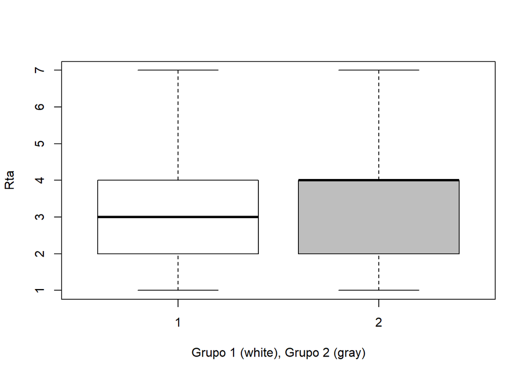

```r
library(ggplot2)

df = read.table("o_d_1.txt", header=T)
boxplot(df$rta[df$exp == 1], df$rta[df$exp == 2], names=c("1", "2"), col=(c("white", "gray")), xlab="Grupo 1 (white), Grupo 2 (gray)", ylab="Rta")
```

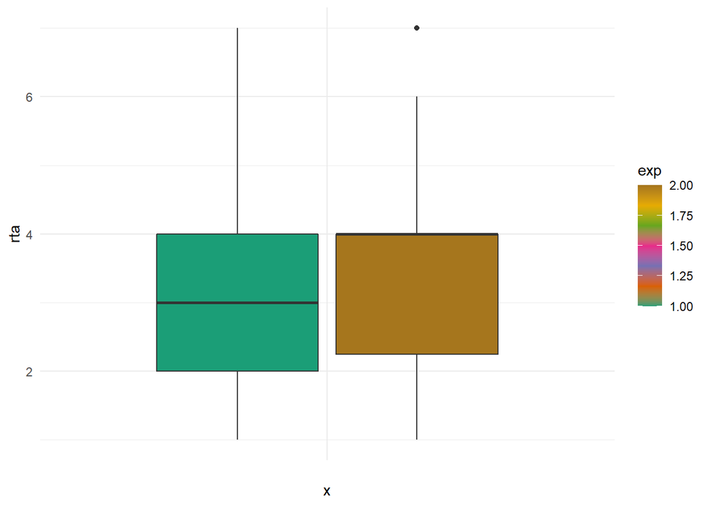

```r
ggplot(df) +
  aes(x = "", y = rta, fill = exp, group = exp) +
  geom_boxplot() +
  scale_fill_distiller(palette = "Dark2", direction = 1) +
  theme_minimal()
```

```r
wilcox.test(df$rta[df$exp == 1], df$rta[df$exp == 2], correct=F)
```

```
##
##  Wilcoxon rank sum test
##
## data:  df$rta[df$exp == 1] and df$rta[df$exp == 2]
## W = 29, p-value = 0.5518
## alternative hypothesis: true location shift is not equal to 0
```

El valor p es 0.55, no está por debajo del nivel de significación, por lo que no hay evidencia para rechazar la igualdad de distribuciones para ambos grupos.

## W de Wilcoxon

Se enmarca en Dicotómica -> Ordinal. Tienen el mismo aspecto que el anterior. En este test se construyen W1 y W2
$$W_i = \sum_{grupo_1} Rangos$$
y se construye un estadístico de contraste z de distribución N(0,1)

Este test se basa en asignar a cada observación un rango según el orden que ocupe dicha observación en el cómputo total de los datos, asignando el rango medio en caso de empates.

```r
# en R se usa wilcox.test, que en lugar de hacer el test de wilcoxon hace el u de mann-whitney
wilcox.test(df$rta[df$exp == 1], df$rta[df$exp == 2], correct=F)
```

```
##
##  Wilcoxon rank sum test
##
## data:  df$rta[df$exp == 1] and df$rta[df$exp == 2]
## W = 29, p-value = 0.5518
## alternative hypothesis: true location shift is not equal to 0
```

## H de Kruskal-Wallis

Se enmarca en O <- N, nominal explica ordinal.También se puede usar en C <- N(nominal explica continua) donde no se cumpla que Y sea normal en cada categoría de la cualitativa X. Al ser ordinal pueden ser tipo likert (1 poco o nada, 2 algo, medio, alto, muy alto) o codificar otros valores (1 -> menos de 0.5 kg, 2 entre 2 y 5, 3 entre 5 y 10…)

Ejemplo

```r
df = read.table("o_n_1.txt", header=T)
summary(df)
```

```
##       rta             exp
##  Min.   :1.000   Min.   :1.000
##  1st Qu.:3.000   1st Qu.:1.000
##  Median :4.000   Median :2.000
##  Mean   :4.318   Mean   :1.909
##  3rd Qu.:5.000   3rd Qu.:2.000
##  Max.   :8.000   Max.   :3.000
```

```r
kruskal.test(rta ~ exp, data=df)
```

```
##
##  Kruskal-Wallis rank sum test
##
## data:  rta by exp
## Kruskal-Wallis chi-squared = 1.3398, df = 2, p-value = 0.5118
```

# Ejercicios

## Nivel 1

### 1

Si Y dicotómica, entonces E(Y) es su proporción muestral.

### 3

Para una misma muestra, un IC95% de una proporción poblacional será siempre más ancho que un IC99%

Intuitivamente esto debería ser falso. Cuanta más confianza hay que tener sobre el valor real del parámetro, más amplio tiene que ser el intervalo de confianza para estar seguros de que el parámetro cae en ese rango.

Por tanto un IC95% de propocion sera siempre menor que un IC99% o sería contradictorio.

Analíticamente

$$IC(1-\alpha)\%(\pi) = \left ( \pi -
z_{1 - \alpha / 2}\sqrt{\pi(1-\pi)\dfrac{1}{n}}, \pi + z_{1 - \alpha /
2}\sqrt{\pi(1-\pi)\dfrac{1}{n}} \right )$$

Para una misma muestra, podemos considerar $\sqrt{\pi(1-\pi)\dfrac{1}{n}}$ constante
$$IC(1-\alpha)\%(\pi) = \left ( \pi - z_{1 - \alpha /
2}\underbrace{\sqrt{\pi(1-\pi)\dfrac{1}{n}}}_C, \pi + z_{1 - \alpha / 2}
\underbrace{ \sqrt{\pi(1-\pi)\dfrac{1}{n}} }_{C} \right ) \\
IC(1-\alpha)\%(\pi) = \left ( \pi - z_{1 - \alpha / 2} C, \pi + z_{1 -
\alpha / 2} C \right )$$
Con esta expresión más simple se ve claramente que el intervalo de confianza para una misma muestra depende enteramente del valor de $z_{1-\alpha/2}$. Cuando $\alpha = 0.95$ el valor de dicho z es 1.96. Cuando $\alpha = 0.99$ el valor de z es 2.58.

De esta forma se observa claramente que

$$\pi - z_{1 - \alpha_{0.99} / 2} < \pi - z_{1 - \alpha_{0.95} / 2}$$

Por tanto, para un mayor nivel de confianza, el intervalo se ensancha, y a menor confianza, se estrecha. También se estrecha en función del número de muestras.

### 5

En un CH al ser $\alpha = P(H_1 | H_0)$ y $\beta = P(H_0 | H_1)$ se tiene que $\alpha + \beta = 1$

Esto implica afirmar que $p(H_1 | H_0) + P(H_0 | H_1) = 1$, pero sabemos que esto no es así. De esto se deriva que $p(H_1 | H_0) = 1 - P(H_0 | H_1)$

Sabemos que
$$\begin{align*}
&p(x,y) = p(x|y)p(y) = p(y|x)p(x) \rightarrow \\
&p(H_0,H_1) = p(H_0| H_1) p(H_1) = p(H_1 | H_0) p(H_0) \rightarrow
\\
&\dfrac{p(H_0| H_1) p(H_1)}{p(H_0)} = p(H_1 | H_0) \\
&p(H_0| H_1) \underbrace{\dfrac{p(H_1)}{p(H_0)}}_{Constant, K} =
p(H_1 | H_0) \\
&p(H_0| H_1) K = p(H_1 | H_0) \\
&p(H_0| H_1) \propto p(H_1 | H_0)
\end{align*}$$

Si en nuestra expresión, $p(H_0| H_1) \propto p(H_1 | H_0)$ entonces $\alpha \propto \beta$, o $\alpha K = \beta \rightarrow \alpha K - \beta = 0$, lo que implica que $\alpha K - \beta = \alpha + \beta - 1$.

No es una demostración pero se intuye de esta última expresión que esto sólo es cierto para ciertos valores de alpha y beta, en el cual K tiene que tomar un valor $\dfrac{2b+a-1}{a}$

## Nivel 2

### 2

Si Y = {0, 1}, entonces V{Y} (la varianza de Y) es

$v[Y] = E[(y - E[y])^2] = E[Y^2]-E[Y]^2$ Dado que en una variable dicotómica $E[y] = E[y^2] \rightarrow E[y^2]-E[y]^2 = E[y]-E[y]^2 = E[y](1 - E[y])$

```r
data = rbinom(100, 1, 0.3)
mean(data)
```

```
## [1] 0.27
```

```r
mean(data^2)
```

```
## [1] 0.27
```